# HOMEWORK 2

ilaydacelenk

27/11/2020

```r
#importing the libraries
library(scatterplot3d) # part(a)
library(tidyverse) #filter etc.
library(ggplot2) #plot in reduced dimensions
library(reshape) #melt
library(directlabels)
library(dplyr)
library(DT) #datatable
```

### Introduction:

Given uWaveGestureLibrary, consisting over 4000 instances from 8 people with 8 different gestures, our aim is to visualize the gestures. Then, we will try to apply dimensionality reduction. There are 8 different gesture classes for each axis, x, y and z.

### Tasks:

#### A. Read the Data and Plot an Instance from Each Gesture

```r
#reading the data from repository
x_train=read.table("https://github.com/BU-IE-582/fall20-ilaydacelenk/blob/master/files/HW2_data/uWaveGestureLibrary_X_TRAIN.txt?raw=true")
y_train=read.table("https://github.com/BU-IE-582/fall20-ilaydacelenk/blob/master/files/HW2_data/uWaveGestureLibrary_Y_TRAIN.txt?raw=true")
z_train=read.table("https://github.com/BU-IE-582/fall20-ilaydacelenk/blob/master/files/HW2_data/uWaveGestureLibrary_Z_TRAIN.txt?raw=true")
```

For the x-axis, let’s find the indices where we see each gesture for the first time. It is enough to look at x_train since y_train and z_train will have the same indices for the first occurrences of each gesture.

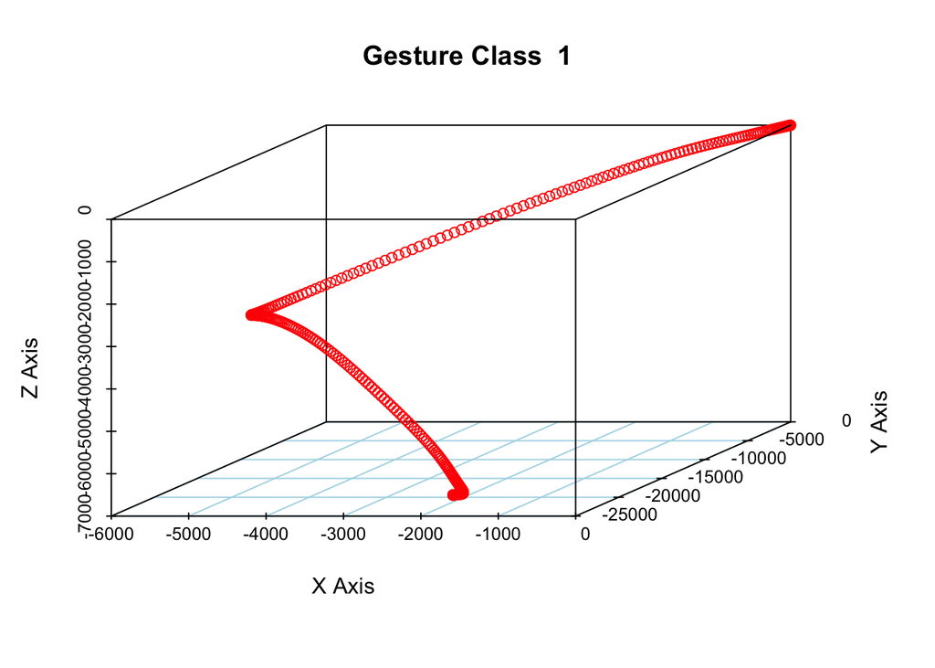

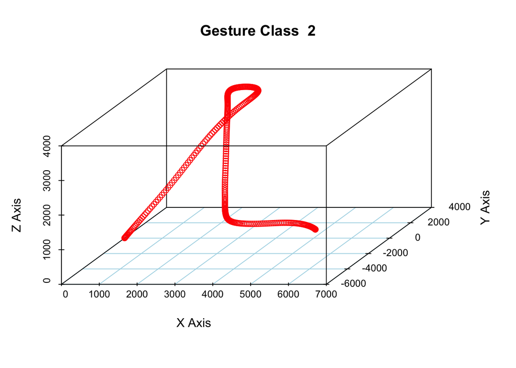

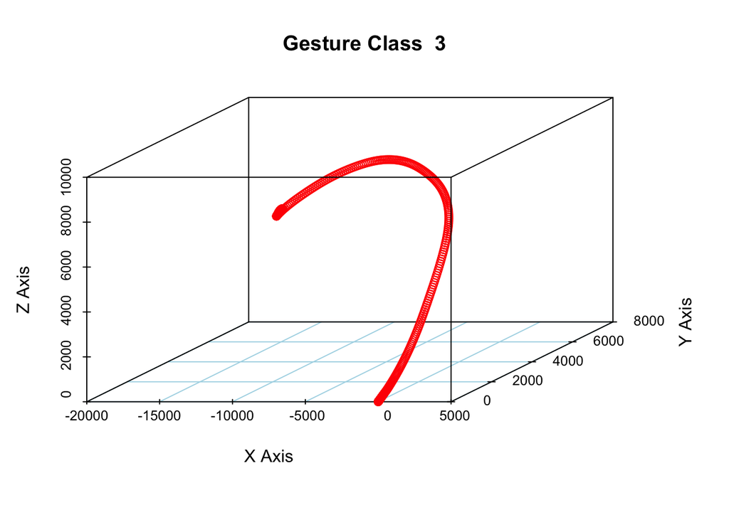

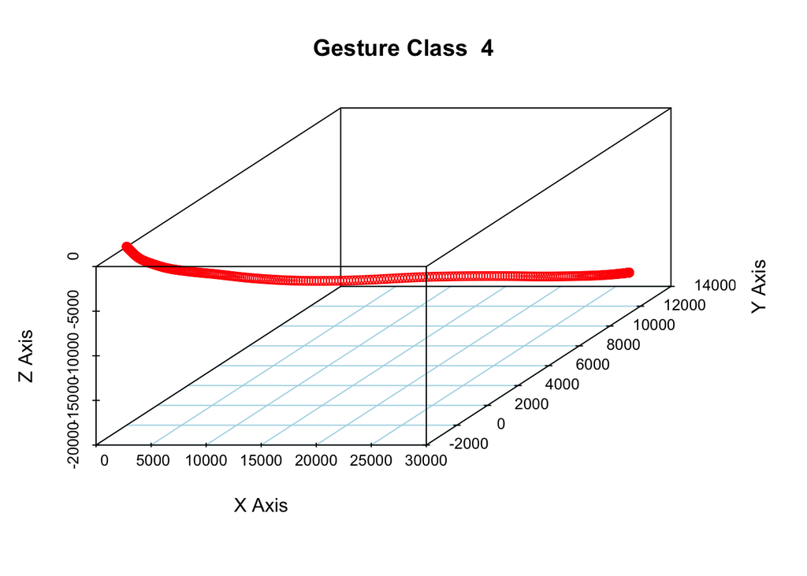

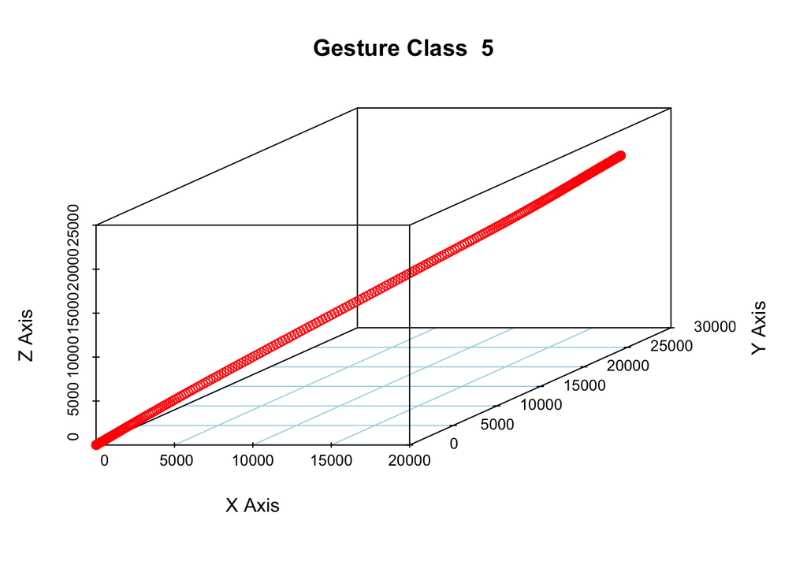

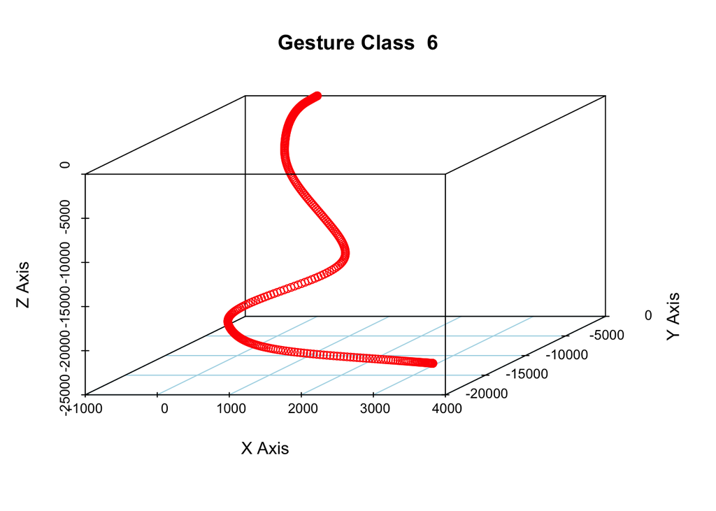

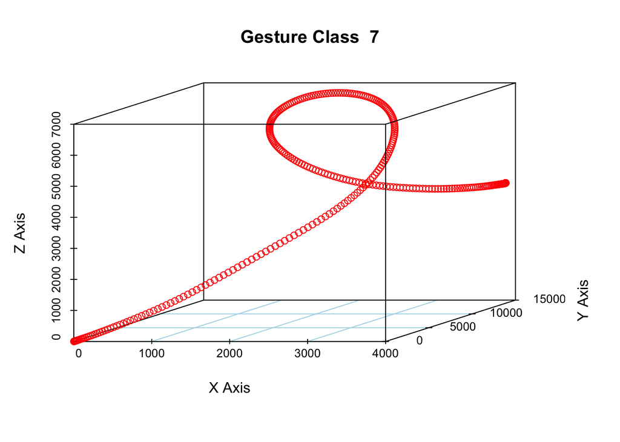

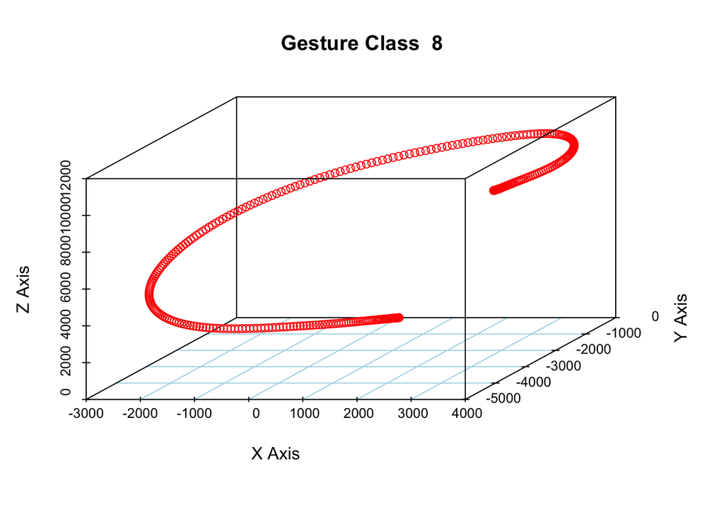

```r
#the first instances when we see gesture of class i, i from 1 to 8
index_vector = c()
for(i in 1:8)
{
  index_vector <- index_vector %>% append(match(i, x_train$V1))
}

# Creating cumulative sum matrices 2 times to get first the velocity vector and then the location vector for each instance
# using velocity(t)=cumsum(acceleration)*change in t
# using position(t)=cumsum(velocity)*change in t

loc_matrix <- function(acc_matrix){
  order_of_instances <- acc_matrix$V1
  acc_matrix$V1 <- 0
  loc <- acc_matrix %>% mutate(V1=0) %>% apply(1, cumsum) %>% t() %>% apply(1, cumsum) %>% t() %>% as.data.frame() %>% mutate(V1=order_of_instances)
  return(loc)
}

x_position <- loc_matrix(x_train) %>% as.matrix()
y_position <- loc_matrix(y_train) %>% as.matrix()
z_position <- loc_matrix(z_train) %>% as.matrix()


plot_3d <- function(indices){
  for(i in 1:8) {
    scatterplot3d(x_position[index_vector[i],-1], y_position[index_vector[i],-1], z_position[index_vector[i],-1], main = paste("Gesture Class ", x_position[index_vector[i],1]) ,xlab = "X Axis", ylab = "Y Axis", zlab = "Z Axis", col.grid="lightblue",type = "p", color = "red")
  }
}

plot_3d(index_vector)
```

#### B. Dimensionality Reduction - PCA on the Whole Data

Here we are dealing with multivariate time series and we would like to reduce it to a univariate time series. In order to achieve this, we transform the data into the long format first.

Column V2 is time 1 and column V316 represents the time index 315.

```r
x_long <- x_position %>% as.data.frame() %>% mutate(id = seq.int(nrow(x_position))) %>% melt(id.vars = c("id", "V1")) %>% transmute(time_series_id=id, time_index=variable, X=value, class=V1)

y_long <- y_position %>% as.data.frame() %>% mutate(id = seq.int(nrow(x_position))) %>% melt(id.vars = c("id", "V1")) %>% transmute(time_series_id=id, time_index=variable, Y=value, class=V1)

z_long <- z_position %>% as.data.frame() %>% mutate(id = seq.int(nrow(x_position))) %>% melt(id.vars = c("id", "V1")) %>% transmute(time_series_id=id, time_index=variable, Z=value, class=V1)

xyz_long <- x_long %>% select(-class) %>% mutate(Y=y_long$Y, Z=z_long$Z, class = x_long$class)  %>% mutate(time_index = sub(".", "", time_index))

xyz_long$time_index <- as.numeric(xyz_long$time_index) - 1
```

```r
pca <- princomp(xyz_long[,3:5], cor=T) #scale differences T
print(summary(pca, loadings=T))
```

```
FALSE Importance of components:
FALSE                           Comp.1    Comp.2    Comp.3
FALSE Standard deviation     1.2724995 1.0380930 0.5505524
FALSE Proportion of Variance 0.5397517 0.3592124 0.1010360
FALSE Cumulative Proportion  0.5397517 0.8989640 1.0000000
FALSE
FALSE Loadings:
FALSE   Comp.1 Comp.2 Comp.3
FALSE X  0.209  0.908  0.362
FALSE Y  0.723  0.105 -0.683
FALSE Z  0.658 -0.404  0.635
```

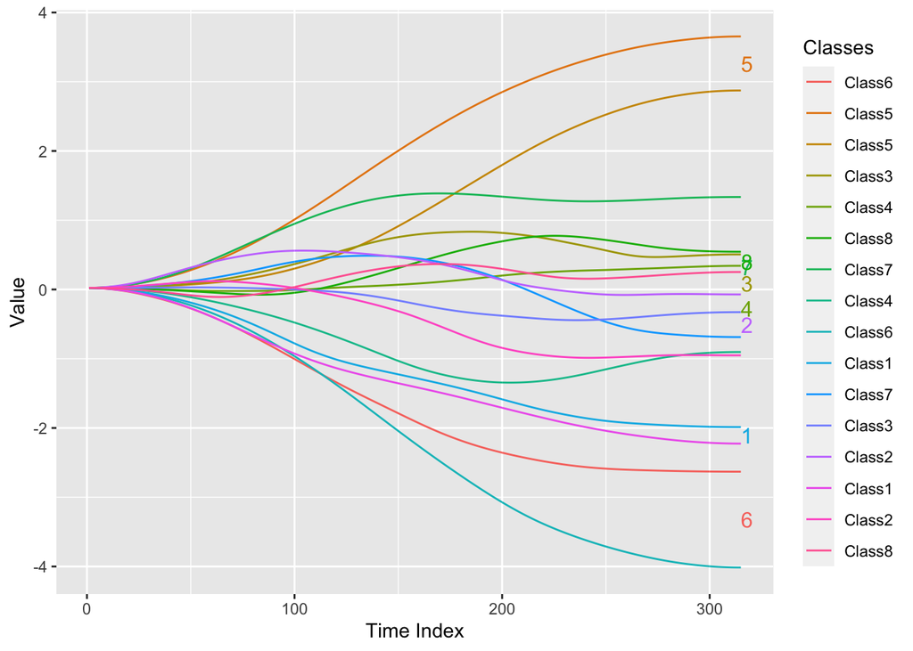

```r
xyz_long_uni <- xyz_long %>% mutate(value = predict(pca,xyz_long[,3:5])[,1]) %>% select(-X, -Y, -Z)

ex_class <- xyz_long_uni %>% filter(time_series_id %in% c(11, 17, 15, 20, 4, 13, 5, 8, 2, 3, 1, 10, 7, 12, 6, 21)) %>% mutate(time_series_id = as_factor(time_series_id), class = as_factor(class))

ggplot(ex_class, aes(x=time_index, y=value, colour=time_series_id)) + geom_line() + xlab("Time Index") + ylab("Value") + theme(plot.title=element_text(hjust = 0.5)) + scale_color_discrete(name = "Classes", labels = c("Class6", "Class5", "Class5", "Class3", "Class4", "Class8", "Class7", "Class4", "Class6", "Class1", "Class7", "Class3", "Class2", "Class1", "Class2", "Class8")) + geom_dl(aes(label = class), method = list(dl.combine("last.points")), cex = 0.8)
```

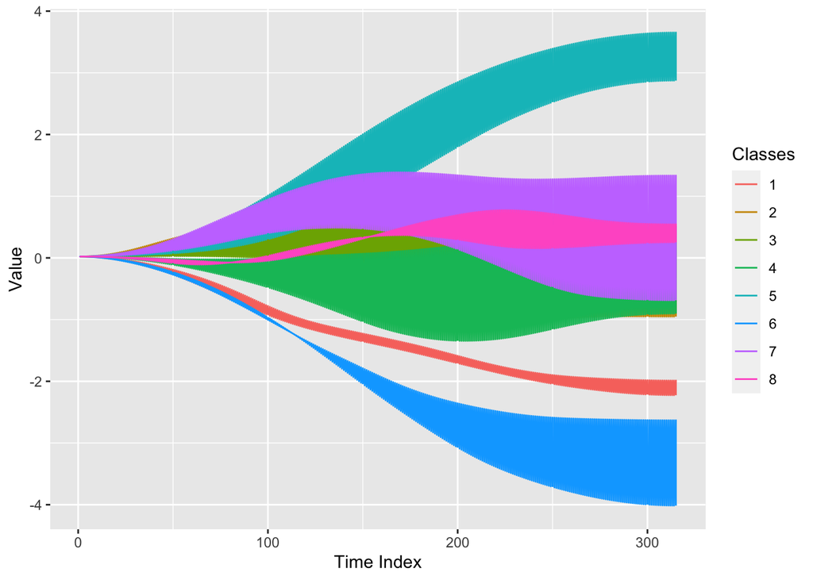

```r
ggplot(ex_class, aes(x=time_index, y=value, colour=class)) + geom_line() + xlab("Time Index") + ylab("Value") + theme(plot.title=element_text(hjust = 0.5)) + scale_color_discrete(name = "Classes")
```

#### C. Dimensionality Reduction - PCA on the Data from Each Gesture

Using the long format for the position data, we apply PCA on X, Y and Z values for each gesture. This can be achieved by filtering the data in long format.

According to the PCA results, with respect to the order of the gestures, the proportions of variance covered by the first components are approximately 0.56, 0.42, 0.50, 0.55, 0.66, 0.60, 0.56 and 0.50.

Since this analysis made on each gesture separately, the linear combinations of X, Y and Z coordinates have different coefficients. For example, for gesture 8, we have 0.664*X+0.337*Y+0.668*Z. With the PCA applied on the whole data, we had 0.209*X + 0.723*Y + 0.658*Z. The coefficients of X coordinates have a huge difference.

Generally, same gestures follow similar graphs. But when we plot them all together, it is observed that different gestures also follow a similar pattern. This shows that this may not be a very good method to distinguish gestures.

```r
xyz_long_1 <- xyz_long %>% filter(class==1)
pca1 <- princomp(xyz_long_1[,3:5], cor=T) #scale differences T
print(summary(pca1, loadings=T))
```

```
FALSE Importance of components:
FALSE                           Comp.1    Comp.2    Comp.3
FALSE Standard deviation     1.2932492 1.0091473 0.5559931
FALSE Proportion of Variance 0.5574978 0.3394594 0.1030428
FALSE Cumulative Proportion  0.5574978 0.8969572 1.0000000
FALSE
FALSE Loadings:
FALSE   Comp.1 Comp.2 Comp.3
FALSE X  0.119  0.973  0.198
FALSE Y  0.693 -0.224  0.685
FALSE Z  0.711        -0.701
```

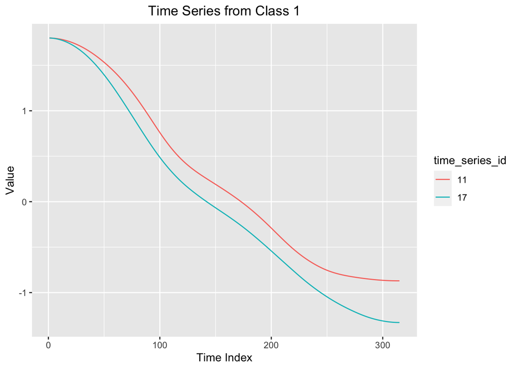

```r
xyz_long_uni_1 <- xyz_long_1 %>% mutate(value = predict(pca1,xyz_long_1[,3:5])[,1]) %>% select(-X, -Y, -Z) %>% filter(time_series_id==11 | time_series_id==17) %>% mutate(time_series_id = as_factor(time_series_id))
ggplot(xyz_long_uni_1) + geom_line(aes(x=time_index, y=value, colour=time_series_id)) + xlab("Time Index") + ylab("Value") + theme(plot.title=element_text(hjust = 0.5)) + ggtitle("Time Series from Class 1")
```

```r
xyz_long_2 <- xyz_long %>% filter(class==2)
pca2 <- princomp(xyz_long_2[,3:5], cor=T) #scale differences T
print(summary(pca2, loadings=T))
```

```
FALSE Importance of components:
FALSE                           Comp.1    Comp.2    Comp.3
FALSE Standard deviation     1.1286537 0.9457021 0.9120243
FALSE Proportion of Variance 0.4246197 0.2981175 0.2772628
FALSE Cumulative Proportion  0.4246197 0.7227372 1.0000000
FALSE
FALSE Loadings:
FALSE   Comp.1 Comp.2 Comp.3
FALSE X  0.535  0.814  0.224
FALSE Y  0.613 -0.192 -0.767
FALSE Z  0.581 -0.548  0.602
```

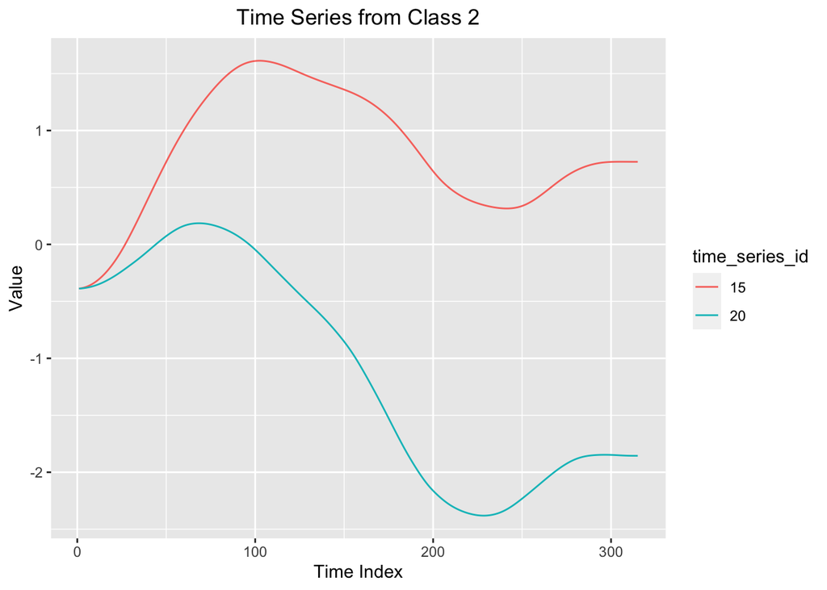

```r
xyz_long_uni_2 <- xyz_long_2 %>% mutate(value = predict(pca2,xyz_long_2[,3:5])[,1]) %>% select(-X, -Y, -Z) %>% filter(time_series_id==15 | time_series_id==20) %>% mutate(time_series_id = as_factor(time_series_id))
ggplot(xyz_long_uni_2) + geom_line(aes(x=time_index, y=value, colour=time_series_id)) + xlab("Time Index") + ylab("Value") + theme(plot.title=element_text(hjust = 0.5)) + ggtitle("Time Series from Class 2")
```

```r
xyz_long_3 <- xyz_long %>% filter(class==3)
pca3 <- princomp(xyz_long_3[,3:5], cor=T) #scale differences T
print(summary(pca3, loadings=T))
```

```
FALSE Importance of components:
FALSE                           Comp.1    Comp.2    Comp.3
FALSE Standard deviation     1.2156489 1.0027730 0.7187794
FALSE Proportion of Variance 0.4926008 0.3351846 0.1722146
FALSE Cumulative Proportion  0.4926008 0.8277854 1.0000000
FALSE
FALSE Loadings:
FALSE   Comp.1 Comp.2 Comp.3
FALSE X  0.709         0.705
FALSE Y  0.371  0.847 -0.380
FALSE Z -0.599  0.532  0.599
```

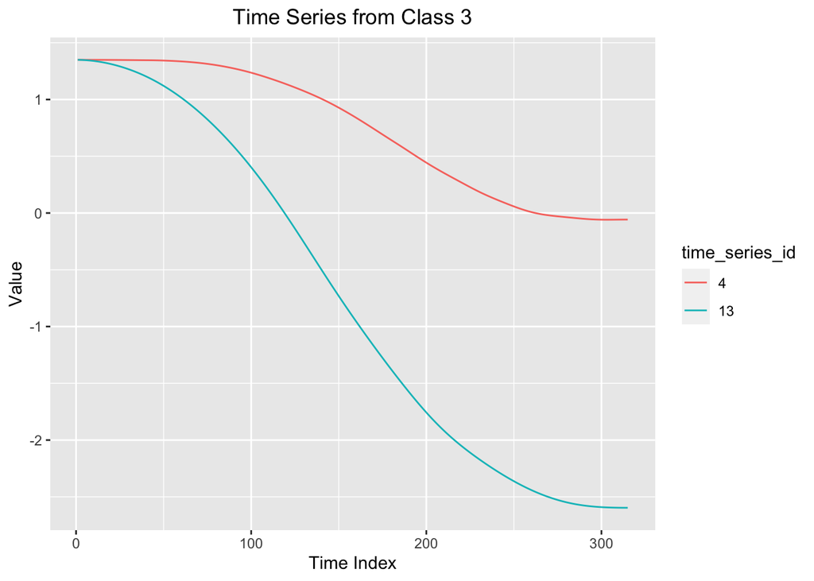

```r
xyz_long_uni_3 <- xyz_long_3 %>% mutate(value = predict(pca3,xyz_long_3[,3:5])[,1]) %>% select(-X, -Y, -Z) %>% filter(time_series_id==4 | time_series_id==13) %>% mutate(time_series_id = as_factor(time_series_id))
ggplot(xyz_long_uni_3) + geom_line(aes(x=time_index, y=value, colour=time_series_id)) + xlab("Time Index") + ylab("Value") + theme(plot.title=element_text(hjust = 0.5)) + ggtitle("Time Series from Class 3")
```

```r
xyz_long_4 <- xyz_long %>% filter(class==4)
pca4 <- princomp(xyz_long_4[,3:5], cor=T) #scale differences T
print(summary(pca4, loadings=T))
```

```
FALSE Importance of components:
FALSE                           Comp.1    Comp.2    Comp.3
FALSE Standard deviation     1.2855781 0.9914895 0.6035210
FALSE Proportion of Variance 0.5509037 0.3276838 0.1214125
FALSE Cumulative Proportion  0.5509037 0.8785875 1.0000000
FALSE
FALSE Loadings:
FALSE   Comp.1 Comp.2 Comp.3
FALSE X  0.702         0.711
FALSE Y  0.674  0.285 -0.681
FALSE Z -0.230  0.958  0.173
```

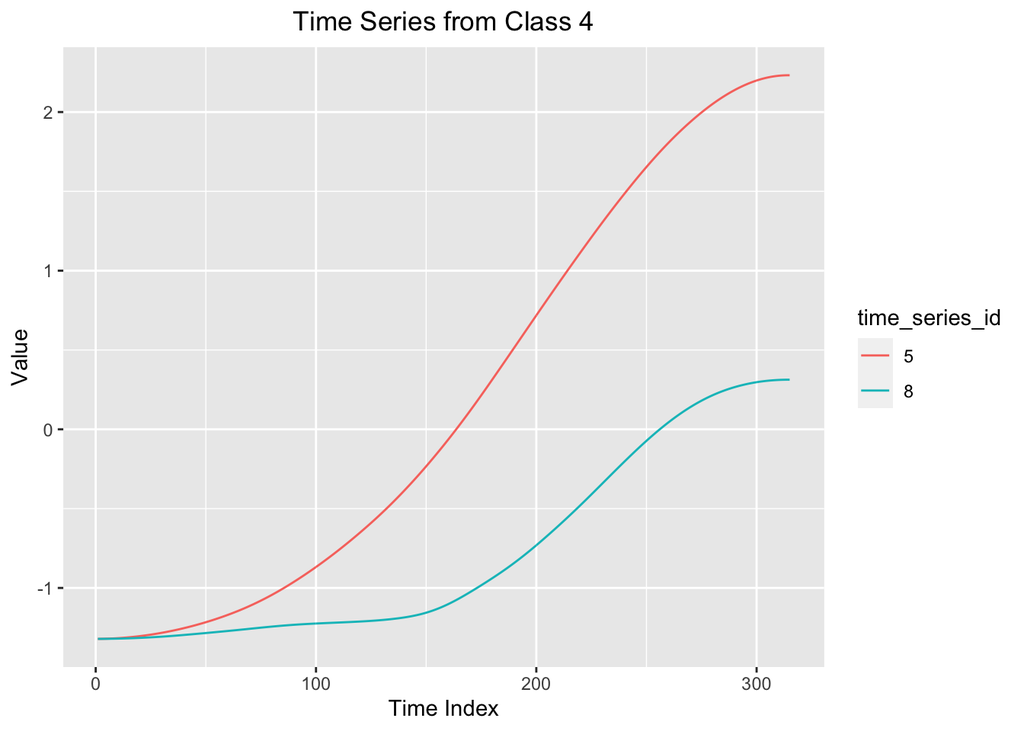

```r
xyz_long_uni_4 <- xyz_long_4 %>% mutate(value = predict(pca4,xyz_long_4[,3:5])[,1]) %>% select(-X, -Y, -Z) %>% filter(time_series_id==5 | time_series_id==8) %>% mutate(time_series_id = as_factor(time_series_id))
ggplot(xyz_long_uni_4) + geom_line(aes(x=time_index, y=value, colour=time_series_id)) + xlab("Time Index") + ylab("Value") + theme(plot.title=element_text(hjust = 0.5)) + ggtitle("Time Series from Class 4")
```

```r
xyz_long_5 <- xyz_long %>% filter(class==5)
pca5 <- princomp(xyz_long_5[,3:5], cor=T) #scale differences T
print(summary(pca5, loadings=T))
```

```
FALSE Importance of components:
FALSE                           Comp.1    Comp.2     Comp.3
FALSE Standard deviation     1.4038307 0.9685920 0.30180949
FALSE Proportion of Variance 0.6569135 0.3127235 0.03036299
FALSE Cumulative Proportion  0.6569135 0.9696370 1.00000000
FALSE
FALSE Loadings:
FALSE   Comp.1 Comp.2 Comp.3
FALSE X  0.245  0.970
FALSE Y  0.685 -0.177  0.707
FALSE Z  0.686 -0.170 -0.708
```

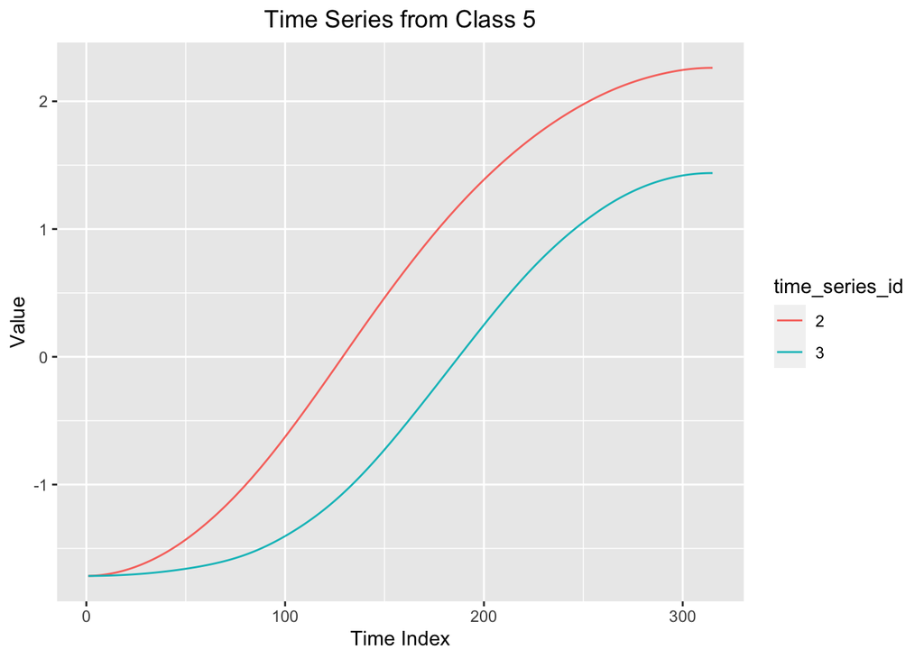

```r
xyz_long_uni_5 <- xyz_long_5 %>% mutate(value = predict(pca5,xyz_long_5[,3:5])[,1]) %>% select(-X, -Y, -Z) %>% filter(time_series_id==2 | time_series_id==3) %>% mutate(time_series_id = as_factor(time_series_id))
ggplot(xyz_long_uni_5) + geom_line(aes(x=time_index, y=value, colour=time_series_id)) + xlab("Time Index") + ylab("Value") + theme(plot.title=element_text(hjust = 0.5)) + ggtitle("Time Series from Class 5")
```

```r
xyz_long_6 <- xyz_long %>% filter(class==6)
pca6 <- princomp(xyz_long_6[,3:5], cor=T) #scale differences T
print(summary(pca6, loadings=T))
```

```
FALSE Importance of components:
FALSE                           Comp.1    Comp.2     Comp.3
FALSE Standard deviation     1.3400570 0.9638120 0.52470332
FALSE Proportion of Variance 0.5985843 0.3096445 0.09177119
FALSE Cumulative Proportion  0.5985843 0.9082288 1.00000000
FALSE
FALSE Loadings:
FALSE   Comp.1 Comp.2 Comp.3
FALSE X  0.291  0.955
FALSE Y -0.671  0.251 -0.698
FALSE Z -0.682  0.162  0.713
```

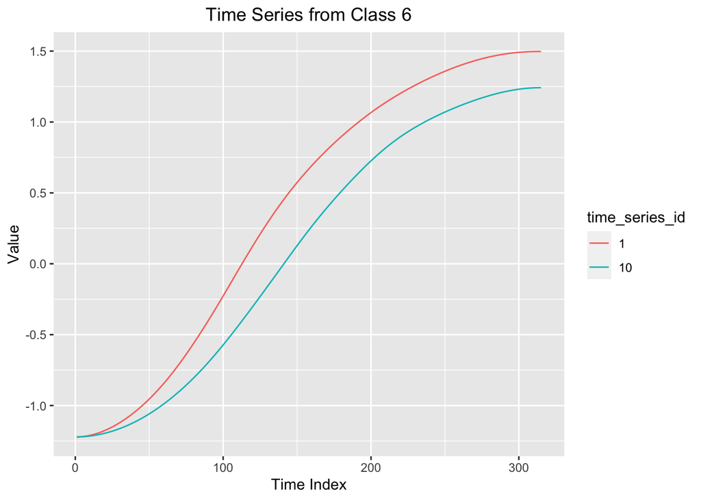

```r
xyz_long_uni_6 <- xyz_long_6 %>% mutate(value = predict(pca6,xyz_long_6[,3:5])[,1]) %>% select(-X, -Y, -Z) %>% filter(time_series_id==1 | time_series_id==10) %>% mutate(time_series_id = as_factor(time_series_id))
ggplot(xyz_long_uni_6) + geom_line(aes(x=time_index, y=value, colour=time_series_id)) + xlab("Time Index") + ylab("Value") + theme(plot.title=element_text(hjust = 0.5)) + ggtitle("Time Series from Class 6")
```

```r
xyz_long_7 <- xyz_long %>% filter(class==7)
pca7 <- princomp(xyz_long_7[,3:5], cor=T) #scale differences T
print(summary(pca7, loadings=T))
```

```
FALSE Importance of components:
FALSE                           Comp.1    Comp.2    Comp.3
FALSE Standard deviation     1.2971922 0.8883869 0.7266781
FALSE Proportion of Variance 0.5609026 0.2630771 0.1760203
FALSE Cumulative Proportion  0.5609026 0.8239797 1.0000000
FALSE
FALSE Loadings:
FALSE   Comp.1 Comp.2 Comp.3
FALSE X  0.596  0.487  0.639
FALSE Y  0.632  0.207 -0.747
FALSE Z  0.496 -0.849  0.184
```

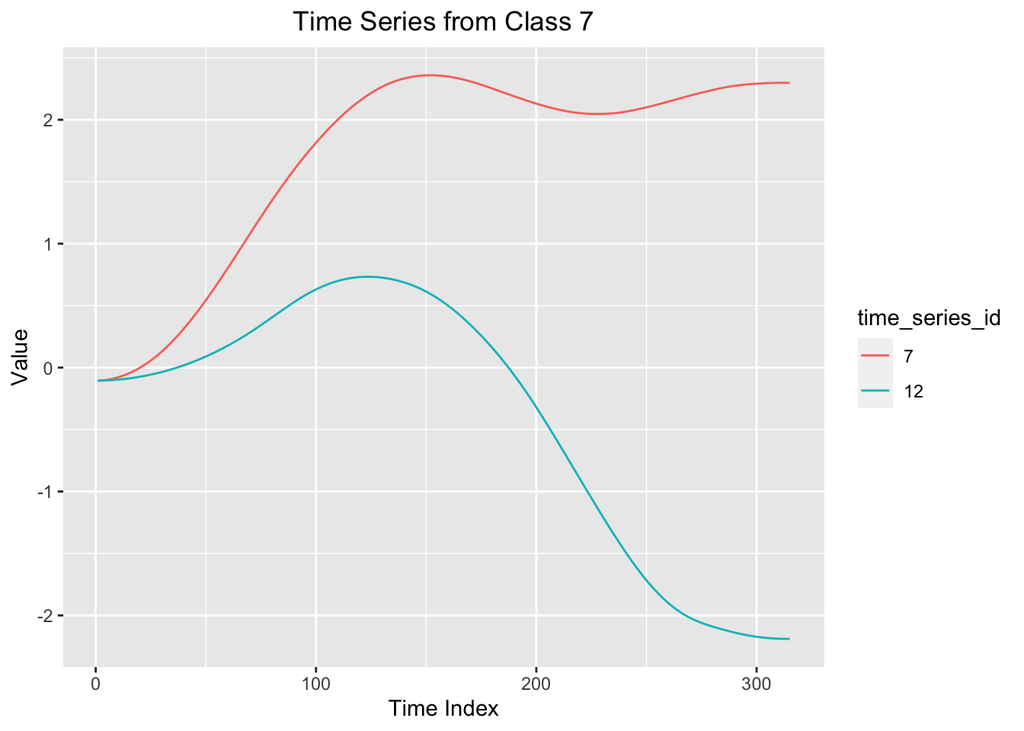

```r
xyz_long_uni_7 <- xyz_long_7 %>% mutate(value = predict(pca7,xyz_long_7[,3:5])[,1]) %>% select(-X, -Y, -Z) %>% filter(time_series_id==7 | time_series_id==12) %>% mutate(time_series_id = as_factor(time_series_id))
ggplot(xyz_long_uni_7) + geom_line(aes(x=time_index, y=value, colour=time_series_id)) + xlab("Time Index") + ylab("Value") + theme(plot.title=element_text(hjust = 0.5)) + ggtitle("Time Series from Class 7")
```

```r
xyz_long_8 <- xyz_long %>% filter(class==8)
pca8 <- princomp(xyz_long_8[,3:5], cor=T) #scale differences T
print(summary(pca8, loadings=T))
```

```
FALSE Importance of components:
FALSE                           Comp.1    Comp.2    Comp.3
FALSE Standard deviation     1.2203138 0.9683089 0.7571078
FALSE Proportion of Variance 0.4963886 0.3125407 0.1910707
FALSE Cumulative Proportion  0.4963886 0.8089293 1.0000000
FALSE
FALSE Loadings:
FALSE   Comp.1 Comp.2 Comp.3
FALSE X  0.664  0.253  0.704
FALSE Y  0.337 -0.941
FALSE Z  0.668  0.223 -0.710
```

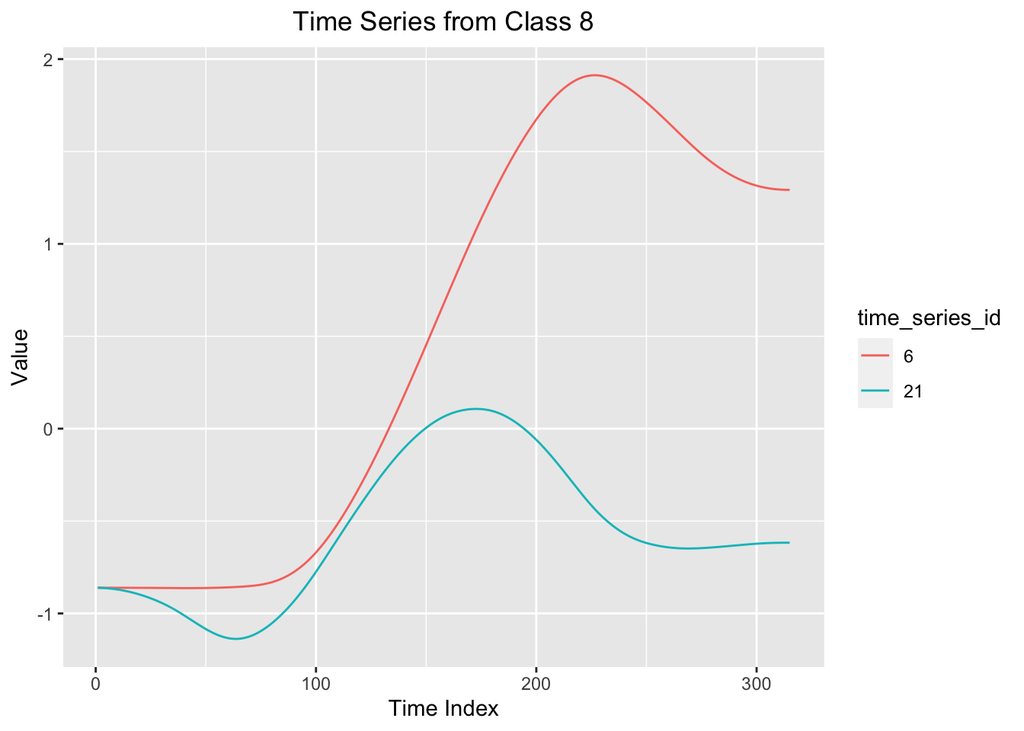

```r
xyz_long_uni_8 <- xyz_long_8 %>% mutate(value = predict(pca8,xyz_long_8[,3:5])[,1]) %>% select(-X, -Y, -Z) %>% filter(time_series_id==6 | time_series_id==21) %>% mutate(time_series_id = as_factor(time_series_id))
ggplot(xyz_long_uni_8) + geom_line(aes(x=time_index, y=value, colour=time_series_id)) + xlab("Time Index") + ylab("Value") + theme(plot.title=element_text(hjust = 0.5)) + ggtitle("Time Series from Class 8")
```

#### D. Multidimensional Scaling

After implementing multimensional scaling, the corresponding points to each gesture is plotted on the graph. This does not create a useful way to separate gestures. For example, even though gestures 1 and 5 are distinguishable, gestures 1 and 6 are almost indistinguishable.

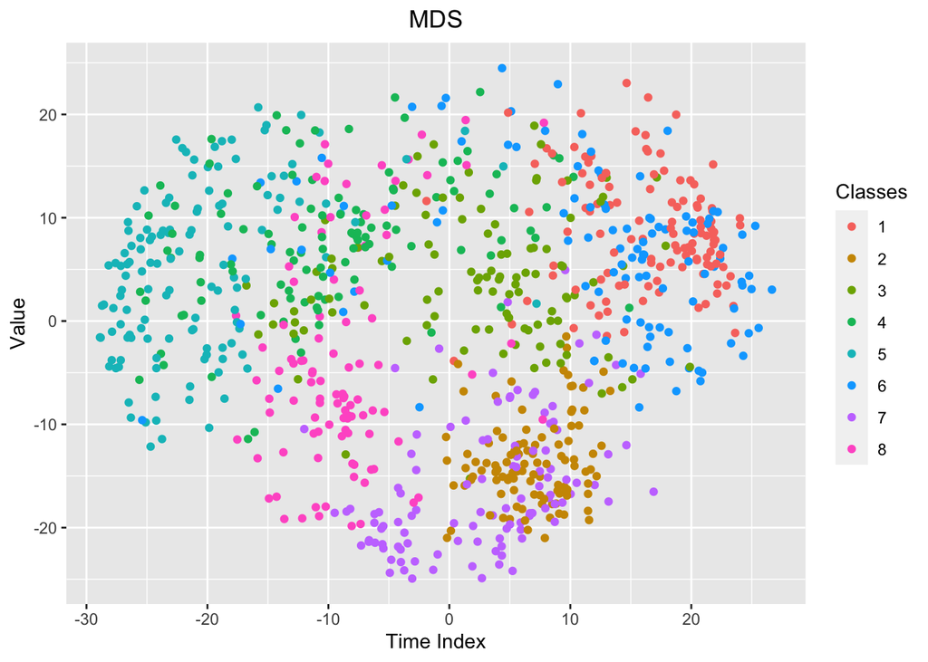

```r
data_binded_columns<-cbind(x_train,y_train[,-1],z_train[,-1])
data_binded_columns[,-1]=scale(data_binded_columns[,-1])
distance = as.matrix(dist(data_binded_columns[,-1], method = "euclidean"))
fit <- cmdscale(distance, k=2) #choose dimension as 2
fit_data <- data_binded_columns %>% select(V1) %>% mutate(coord1=fit[,1], coord2=fit[,2], Classes = as_factor(V1))

ggplot(fit_data) + geom_point(aes(x=coord1, y=coord2, colour=Classes)) + xlab("Time Index") + ylab("Value") + theme(plot.title=element_text(hjust = 0.5)) + ggtitle("MDS")
```

### Reference

[1] J. Liu, Z. Wang, L. Zhong, J. Wickramasuriya, and V. Vasudevan. uWave: Accelerometer-based personalized gesture recognition and its applications. Pervasive Computing and Communications, IEEE International Conference on, 0:1-9, 2009. (link: https://www.recg.org/publications/liu09percom.pdf)